## Exercise 1

Begin with describing and fitting a full model in which the intercepts and slopes of the extinction times versus numbers of pairs may be different in all four combinations of size and migratory status.

```
##
## Call:
## lm(formula = Time ~ Pairs * Size * Status, data = bird_data)
##
## Residuals:
##     Min      1Q  Median      3Q     Max
## -14.769  -3.644  -0.652   1.128  49.831
##
## Coefficients:
##                     Estimate Std. Error t value Pr(>|t|)
## (Intercept)           0.7775     6.6831   0.116    0.908
## Pairs                 1.2397     1.7232   0.719    0.475
## SizeS                 0.1759     8.3168   0.021    0.983
## StatusR               4.0489     7.8704   0.514    0.609
## Pairs:SizeS          -0.9058     2.4206  -0.374    0.710
## Pairs:StatusR         0.5317     2.0037   0.265    0.792
## SizeS:StatusR        -9.4013     9.8736  -0.952    0.345
## Pairs:SizeS:StatusR   2.0047     2.7218   0.737    0.465
##
## Residual standard error: 9.237 on 54 degrees of freedom
## Multiple R-squared:  0.3398, Adjusted R-squared:  0.2542
## F-statistic:  3.97 on 7 and 54 DF,  p-value: 0.001446
```

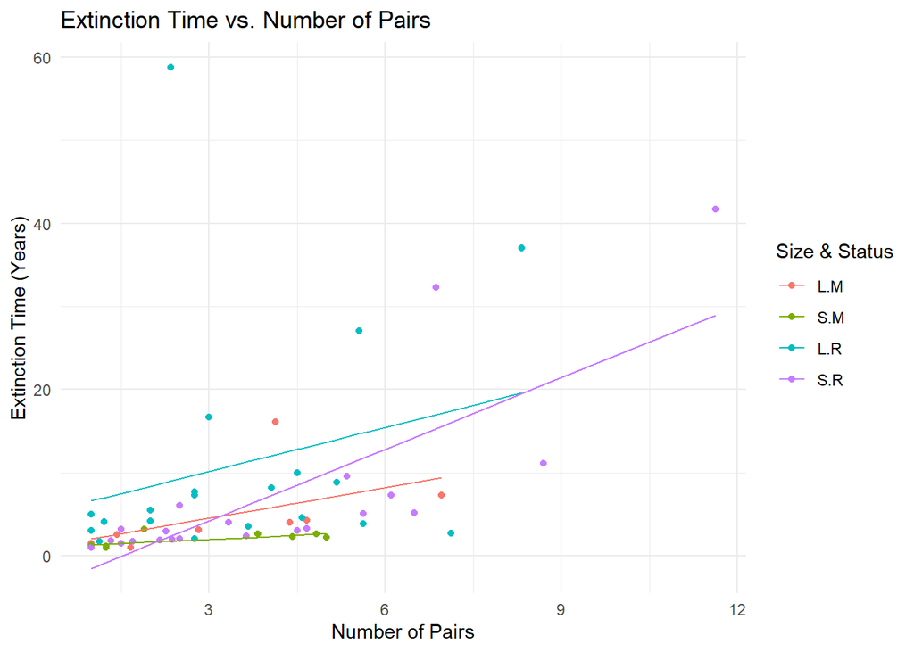

## Exercise 2

Examine the data set for possible transformations and outliers: Make a residual plot from the fit of the model. What can you tell based on the residual plot? (i.e. fit of the model/ possible transformations needed + outliers)?

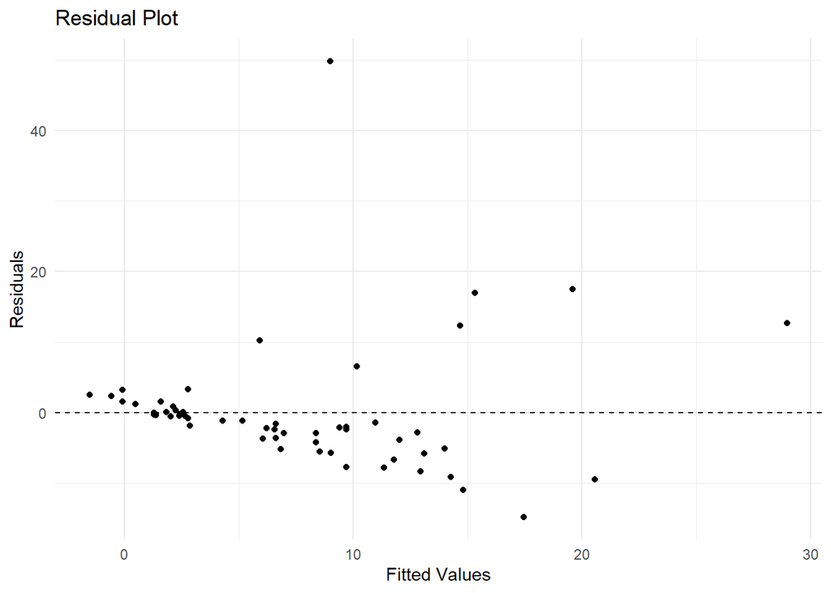

When examining the residuals, we look for:

1. Homoscedasticity: The residuals should have constant variance across the range of fitted values. If the spread of residuals seems to change across the fitted values, a transformation may be needed.

The variance of the residuals becomes bigger and bigger as the value being fitted (number of pairs + extinction time) goes up.

2. Independence: There should be no patterns or trends in the residuals. If you notice any patterns or trends, it might indicate that a variable is missing from the model, or a transformation is needed.

There appears to be a slight downward slope pattern.

3. Outliers: Look for points that stand out from the rest, as they may be outliers. Investigate these points further to determine if they are errors or if they represent genuine observations. You may consider removing outliers if they are affecting the model’s performance.

Biggest outlier:

- Species: Raven
- Time: 58.82
- Pairs: 2.35
- Size: L
- Status: R
4. Normality: Ideally, the residuals should be approximately normally distributed. If the residuals exhibit a non-normal distribution, you may need to consider a transformation of the dependent variable or use a different modeling approach.

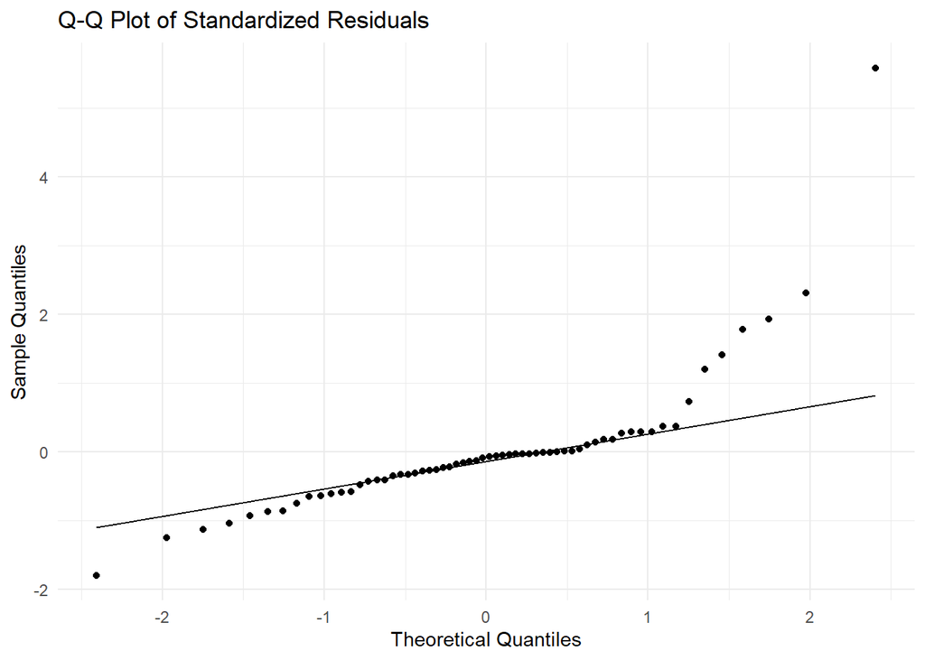

The residuals appear to be normally distributed except for the lower and upper ends, where they become more skewed, this suggests that a data transformation may be necessarry.

## Exercise 3

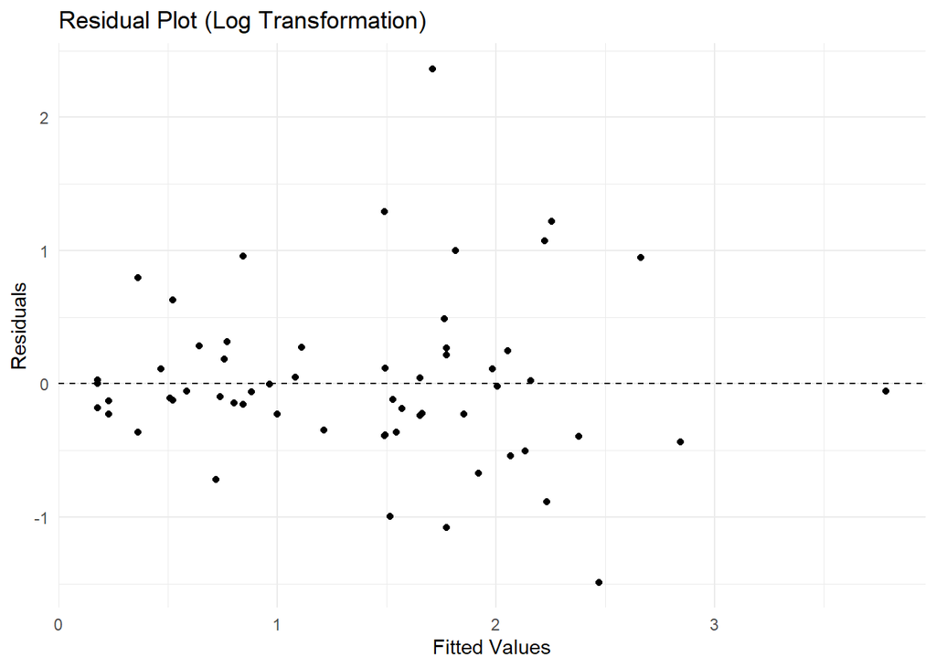

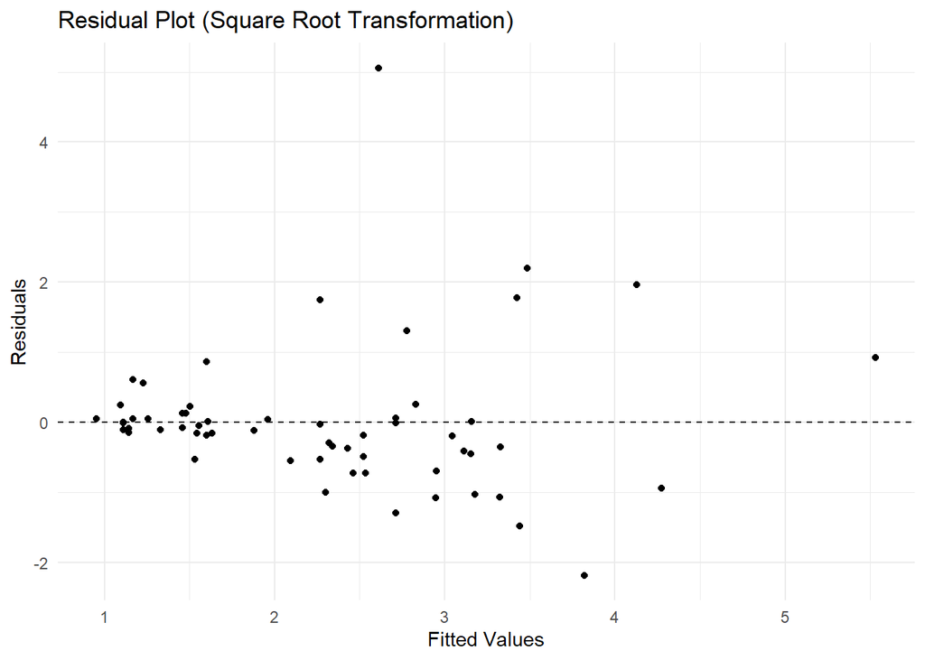

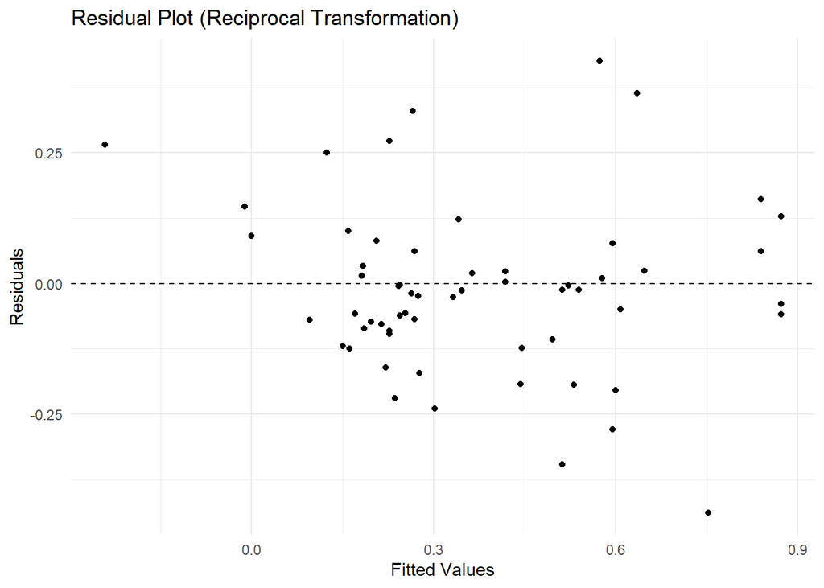

Immediately, we can tell that the square transformation does not improve the model. To compare the log and reciprocal transformation, we will use Q-Q plots again.

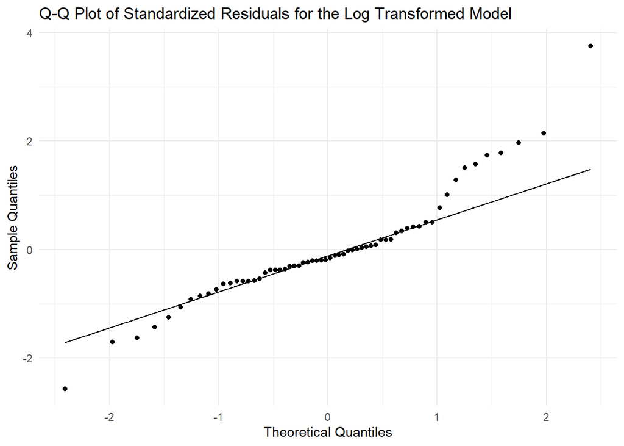

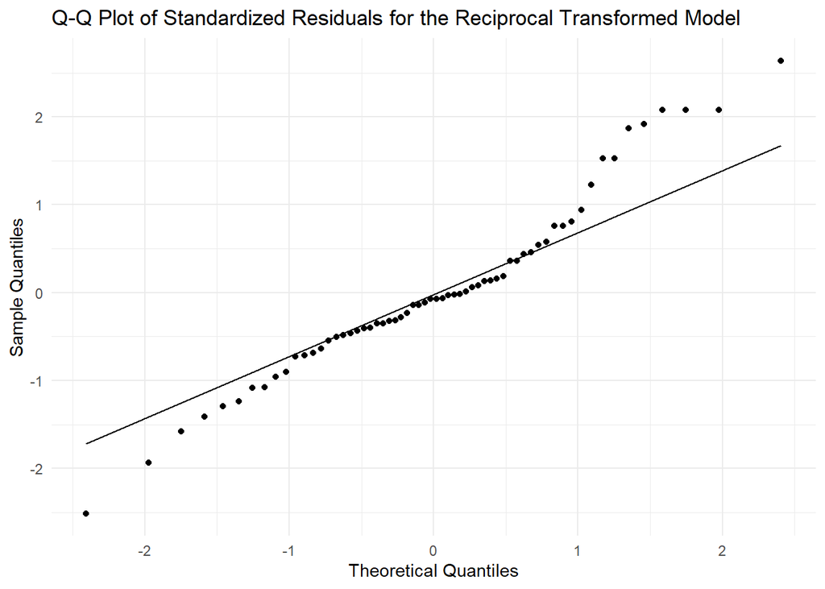

Based on the Q-Q plots, the log transformation seems to be the best fit for the majority of the fitted data points.

## Exercise 4

Outliers can have a significant impact on the results of a statistical analysis, including regression models. There is one outlier with nearly 60 years before extinction and possibly other outliers at the other end of the scale. Here’s how these outliers can affect the results:

1. Influence on model parameters: Outliers can skew the estimates of the regression coefficients, resulting in biased estimates of the relationship between the independent and dependent variables. This can lead to incorrect conclusions about the strength and direction of the associations.
2. Reduced model accuracy: Outliers can increase the overall error in the model, reducing its accuracy and predictive power. This can make it difficult to generalize the model to new data or other similar situations.
3. Distortion of the residual distribution: Outliers can cause the residuals to deviate from normality, violating the assumptions of linear regression models. This can affect the reliability of hypothesis tests and confidence intervals derived from the model.

Despite these potential issues, there might be valid reasons to keep the outliers in the dataset:

1. Real-world representation: If the outliers are genuine observations and not a result of data entry errors or other mistakes, they may represent important real-world phenomena that should be considered in the analysis. Removing them could lead to an incomplete or biased understanding of the underlying processes.
2. Insight into extreme cases: Outliers can provide valuable insights into the behavior of the system under extreme conditions. By keeping them in the dataset, you can learn more about how the system responds when pushed to its limits.
3. Robustness of the model: Including outliers in the analysis can help assess the robustness of the model. If the model can account for the presence of outliers and still provide meaningful results, it demonstrates the model’s ability to handle a wider range of situations.

In conclusion, it is essential to carefully assess the potential impact of outliers on the analysis and consider their potential benefits before deciding whether to keep them in the dataset. In some cases, it might be necessary to use robust statistical methods or other techniques to account for the presence of outliers and minimize their influence on the results.

## Exercise 5

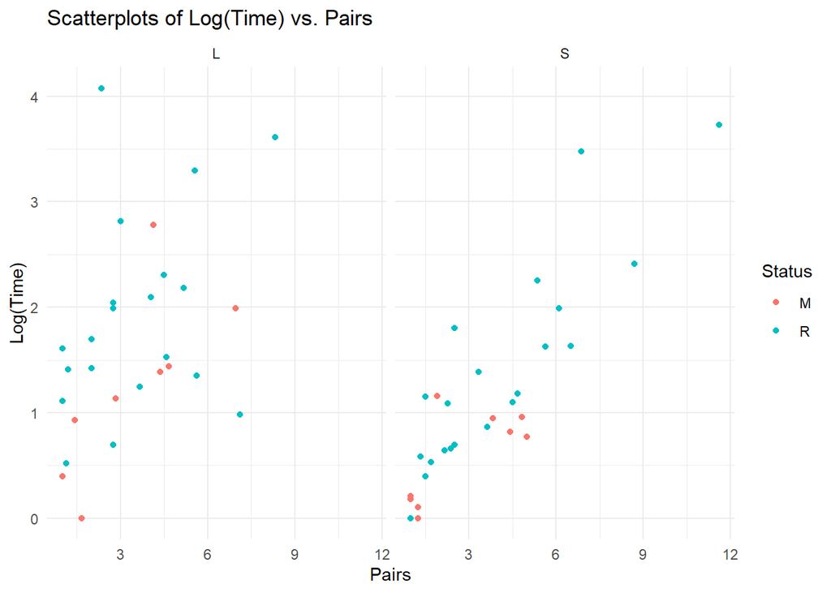

The relationship between log(Time) and Pairs does appear to be a positive linear relationship, thus indicating that a transformation of Pairs is not needed.

The relationship also appears to be more linear than with log-transformed Pairs, as shown below, where a slight curve pattern emerges.

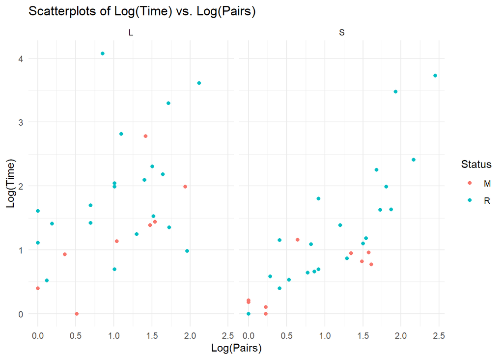

## Exercise 6

### 6.1

```
##
## Call:
## lm(formula = log(Time) ~ Pairs * Size * Status, data = bird_data)
##
## Residuals:
##     Min      1Q  Median      3Q     Max
## -1.4887 -0.3577 -0.1033  0.2065  2.3643
##
## Coefficients:
##                     Estimate Std. Error t value Pr(>|t|)
## (Intercept)           0.1943     0.4716   0.412   0.6819
## Pairs                 0.3141     0.1216   2.583   0.0125 *
## SizeS                -0.2207     0.5869  -0.376   0.7084
## StatusR               1.1412     0.5554   2.055   0.0448 *
## Pairs:SizeS          -0.1089     0.1708  -0.637   0.5266
## Pairs:StatusR        -0.1546     0.1414  -1.093   0.2790
## SizeS:StatusR        -1.0754     0.6967  -1.544   0.1285
## Pairs:SizeS:StatusR   0.2717     0.1921   1.415   0.1629
## ---
## Signif. codes:  0 '***' 0.001 '**' 0.01 '*' 0.05 '.' 0.1 ' ' 1
##
## Residual standard error: 0.6518 on 54 degrees of freedom
## Multiple R-squared:  0.6267, Adjusted R-squared:  0.5783
## F-statistic: 12.95 on 7 and 54 DF,  p-value: 1.219e-09
```

After running this code, you will see the coefficients for each term in the model, including the interactions. To determine whether the slopes are equal for all combinations of “size” and “migratory status,” examine the coefficients for the interaction terms Pairs:Size, Pairs:Status, and Pairs:Size:Status. If the interaction terms are not statistically significant (i.e., their p-values are larger than a chosen significance level, typically 0.05), it suggests that the slopes are not significantly different between the four combinations of “size” and “migratory status.”

Pairs:SizeS: The coefficient is -0.1089 with a p-value of 0.5266, which is not statistically significant at a 0.05 significance level.

Pairs:StatusR: The coefficient is -0.1546 with a p-value of 0.2790, which is not statistically significant at a 0.05 significance level.

Pairs:SizeS:StatusR: The coefficient is 0.2717 with a p-value of 0.1629, which is not statistically significant at a 0.05 significance level.

Since none of the interaction terms are statistically significant, there is not enough evidence to conclude that the slopes for all four combinations of “size” and “migratory status” are different. This suggests that the relationship between “Pairs” and log(“Time”) may not be significantly different among the four groups based on “size” and “migratory status”. However, it is essential to note that a lack of statistical significance does not necessarily mean the slopes are equal; it indicates that there isn’t enough evidence to reject the null hypothesis that the slopes are equal.

### 6.2

Nested models are a series of models where each model is a subset of the previous one. This approach helps in assessing the contribution of variables and their interactions to the overall model fit. To create nested models, start with the simplest model and gradually add variables and interaction terms to evaluate their contributions.

```
## Analysis of Variance Table
##
## Model 1: log(Time) ~ Pairs
## Model 2: log(Time) ~ Pairs + Size
## Model 3: log(Time) ~ Pairs + Size + Status
## Model 4: log(Time) ~ Pairs * Size + Status
## Model 5: log(Time) ~ Pairs * Size * Status
##   Res.Df    RSS Df Sum of Sq       F   Pr(>F)
## 1     60 34.795
## 2     59 27.924  1    6.8710 16.1719 0.000181 ***
## 3     58 24.682  1    3.2424  7.6315 0.007825 **
## 4     57 23.976  1    0.7056  1.6608 0.202995
## 5     54 22.943  3    1.0332  0.8106 0.493550
## ---
## Signif. codes:  0 '***' 0.001 '**' 0.01 '*' 0.05 '.' 0.1 ' ' 1
```

When we move from Model 1 to Model 2 (adding the Size variable), the p-value is 0.000181 (significant at the 0.05 level). This indicates that adding the Size variable significantly improves the model fit.

When we move from Model 2 to Model 3 (adding the Status variable), the p-value is 0.007825 (significant at the 0.05 level). This suggests that adding the Status variable significantly improves the model fit.

When we move from Model 3 to Model 4 (adding the Pairs * Size interaction term), the p-value is 0.202995 (not significant at the 0.05 level). This suggests that adding the Pairs * Size interaction term does not significantly improve the model fit.

When we move from Model 4 to Model 5 (adding the Pairs * Size * Status interaction term), the p-value is 0.493550 (not significant at the 0.05 level). This indicates that adding the Pairs * Size * Status interaction term does not significantly improve the model fit.

Based on the ANOVA results, it seems that Model 3 (Time ~ Pairs + Size + Status) is the most appropriate model for this dataset, as adding interaction terms does not significantly improve the model fit.

## Exercise 7

Based on the findings from previous items, we can create a reduced model using just the Pairs, Size, and Status variables, without interaction terms.

```
##
## Call:
## lm(formula = log(Time) ~ Pairs + Size + Status, data = bird_data)
##
## Residuals:
##      Min       1Q   Median       3Q      Max
## -1.83997 -0.29458 -0.07187  0.21712  2.51691
##
## Coefficients:
##             Estimate Std. Error t value Pr(>|t|)
## (Intercept)  0.43056    0.20706   2.079 0.042011 *
## Pairs        0.26509    0.03679   7.206 1.32e-09 ***
## SizeS       -0.65237    0.16665  -3.915 0.000241 ***
## StatusR      0.50406    0.18261   2.760 0.007717 **
## ---
## Signif. codes:  0 '***' 0.001 '**' 0.01 '*' 0.05 '.' 0.1 ' ' 1
##
## Residual standard error: 0.6523 on 58 degrees of freedom
## Multiple R-squared:  0.5984, Adjusted R-squared:  0.5776
## F-statistic: 28.81 on 3 and 58 DF,  p-value: 1.557e-11
```

[figure not shown]

## Exercise 8

After analyzing the data and accounting for the number of nesting pairs, we can conclude that the number of nesting pairs has a significant impact on the time it takes for a species to become extinct. Larger numbers of nesting pairs tend to result in longer times before extinction.

It is also worth noting that there were a few outliers with unusually large extinction times compared to other species with similar explanatory variable values. These outliers should be further investigated to understand the underlying factors contributing to their atypical extinction times.

Biggest outlier:

- Species: Raven
- Time: 58.82
- Pairs: 2.35
- Size: L
- Status: R

Based on the reduced model, the “theoretical” regression formula for the logarithm of extinction time can be constructed using the coefficients from the summary. The formula would look like this:

$$ln(Time) = 0.43056 + 0.26509 * Pairs -
0.65237 * SizeS + 0.50406 *
StatusR$$

Here,

ln(Time) represents the natural logarithm of the extinction time (note that log() in R defaults to ln);

Pairs is the number of nesting pairs (as a continuous variable);

SizeS is a binary variable indicating the bird size, with 1 for small-sized birds and 0 for large-sized birds;

StatusR is a binary variable indicating the migratory status, with 1 for resident birds and 0 for migratory birds.

The coefficients in the formula represent the effects of each variable on the logarithm of the extinction time while keeping the other variables constant.

For example, an increase in the number of nesting pairs by one unit is associated with an increase in the logarithm of extinction time by 0.26509 units, holding size and migratory status constant. Similarly, small-sized birds have a 0.65237 units lower logarithm of extinction time compared to large-sized birds, holding the number of nesting pairs and migratory status constant.

This formula can be used as a conclusion to describe the relationship between the extinction time and the variables of interest (number of nesting pairs, size, and migratory status) based on the reduced model.